# Methodology

**Tools**

For disk bandwidth test, we use Fio. Fio is short for Flexible IO, a versatile IO workload generator. It was written to benchmark or verify changes to the Linux IO subsystem by Linux developers. Fio is flexible enough to allow detailed workload setups, and it contains the necessary reporting to make sense of the data at completion. Fio is widely used as an industry standard benchmark, stress testing tool, and for IO verification purposes. Fio isn't tied to any OS. It works on any platform from Windows to HP-UX to Android. There are also native IO engines on Linux, Windows, Solaris, etc. This is a key feature to make the measurement repeatable across platforms.

Fio also supports three different types of output formats. The “classic” output is the default which dumps workload statistics at the end of the workload. There's also support for a CSV format called Terse, though that's slowly diminishing in favor of a JSON-based output format. The latter is far more flexible and has the advantage of being simple to parse for people and computers. In this report, we use the Terse format for the output.

**Test Design**

During our measurement, we saw that the bandwidth of random read/write and sequential read/write is very different. To keep the same setting for the test and control the time for each test, we have to consider carefully the size of transfered data, number of parallel threads, number of VMs on one host. If the size is too small, the job finish too quickly, we cannot see the a stable bandwidth of sequential read/write. If the data volume is too big, the random read/write test is take too long to finish. The number of parallel threads also affect a lot on the bandwith (as explained in the result assessment section). We have 5 different servers which have same specs. We do the same test on 5 servers to have a referrent for a good result. We check whether our result is usable by examine at the same time the result from 5 servers. If the result on one server is different from the others, we can conclude that our data were affected too much by other users or processes. On each server, we run same number of Virtual Machines. We run Fio on the physical host with different number of Fio threads (from 1 to 4 concurrent threads). Then with the same configuration, we run it from inside the VMs. We also make the comparison with the case that each VM has only one thread but we increase the number of concurrent running VMs on the same host. We also use identical Operating Systems and identical Os setting across platforms to make sure that the measurement result is relisable.

Our configuration file for Fio has this structure:

```
; sample setting of one thread
[sequential-read]
rw=read
size=(512mb/number_of_parallel_threads)
directory=/home/cloud-user/fiodata
ioengine=libaio
direct=1
iodepth=1/16/32
```

# Result assessment

Import library to use

```python
# Set figure to display inside notebook
%matplotlib inline
####
import numpy as np
from pandas import *
import pandas as pd
import matplotlib.pyplot as plt
from matplotlib import *
import matplotlib.pylab as pylab
import scipy.stats as td
pylab.rcParams['figure.figsize'] = 12, 8  # change default size of figures
```

Reading input to pandas

```python
dtresult = pd.read_csv('data/dtanalysis.csv', delimiter=' ', header=None)
dtdata = dtresult[range(1,21)]
dtindex = dtresult[0]
#dtcolumns=['thread1','thread2','thread3','thread4','thread5','thread6','thread7','thread8',
#         'thread9','thread10','thread11','thread12','thread13','thread14','thread15','thread16',
#         'thread17','thread18','thread19','thread20']
dtdata.index = dtindex.str.replace('T1|T2|T3|T4|T5', '',case=False)
# dtdata.columns = dtcolumns
```

From this point we will only working on data of one host. **We can select the host here**. The tests performed on the 5 servers are the same. So the figures for one host is enough, otherwise it would be redundant. I intended to use the results on other servers for a *reference* of our results. From these data, I'm thinking we can develop some kind of factor that represents the interference on the cluster. Kind of *"similarity coefficience"*. If the similarity (from the result) between the 5 servers is little, then we have too much interference or the figure from one server cannot be a representative. But if similarity is high, then we can conclude that we don't have much interefence that affects on our study.

```python
hostbf1 = range(1,5)
hostbf2 = range(5,9)
hostbf3 = range(9,13)
hostbf4 = range(13,17)
hostbf5 = range(17,21)

selectedhost = hostbf2 # Changing host by defining range (1,5)=bf1, (5,9)=bf2, (9,13)=bf3, (13,17)=bf4, (17,21)=bf5

onehostdata = dtdata[selectedhost]
```

```python
# To calculate the average throughput, we first calculate average throughput each thread has in one test, then again take the
# average of 5 tests
avgtpin1test = onehostdata.T.mean() # Average throughput of each thread/VM in one test
avgtpin5tests = avgtpin1test.groupby(level=0).mean() # Average throughput of each thread/VM in 5 tests
avgtpin5tests = avgtpin5tests / 1024 # Converting to Megabytes/second
```

```python
# Putting average throughput per thread/VM to vector before plotting
bwsrbf = avgtpin5tests.filter(regex="^SRBFTH").tolist()
bwswbf = avgtpin5tests.filter(regex="^SWBFTH").tolist()
bwrrbf = avgtpin5tests.filter(regex="^RRBFTH").tolist()
bwrwbf = avgtpin5tests.filter(regex="^RWBFTH").tolist()
bwsrsvm = avgtpin5tests.filter(regex="^SR1VMTH").tolist()
bwswsvm = avgtpin5tests.filter(regex="^SW1VMTH").tolist()
bwrrsvm = avgtpin5tests.filter(regex="^RR1VMTH").tolist()
bwrwsvm = avgtpin5tests.filter(regex="^RW1VMTH").tolist()
bwsrmvm = avgtpin5tests.filter(regex="^SR[1-4]VMTH1").tolist()
bwswmvm = avgtpin5tests.filter(regex="^SW[1-4]VMTH1").tolist()
bwrrmvm = avgtpin5tests.filter(regex="^RR[1-4]VMTH1").tolist()
bwrwmvm = avgtpin5tests.filter(regex="^RW[1-4]VMTH1").tolist()
```

```python
# Calculate aggregated throughput on each host of each test, then taking the average
aggtpin1test = onehostdata.T.sum() # Aggregate throughput on each host in one test
avgaggtpintestgrouped = aggtpin1test.groupby(level=0)
avgaggtpin5tests = avgaggtpintestgrouped.mean() # Then calculate the average of the total throughput through 5 tests
avgaggtpin5tests = avgaggtpin5tests / 1024 # Convert to MB/s
ciaggtpin5tests = avgaggtpintestgrouped.aggregate(lambda x: np.std(x) / np.sqrt(x.count()) * 1.96) # Confident interval of 95%
ciaggtpin5tests = ciaggtpin5tests / 1024 # Convert to same scale with mean
```

```python
# Putting average aggregate throughput to vector before plotting
aggbwsrbf = avgaggtpin5tests.filter(regex="^SRBFTH").tolist()
aggbwswbf = avgaggtpin5tests.filter(regex="^SWBFTH").tolist()
aggbwrrbf = avgaggtpin5tests.filter(regex="^RRBFTH").tolist()
aggbwrwbf = avgaggtpin5tests.filter(regex="^RWBFTH").tolist()
aggbwsrsvm = avgaggtpin5tests.filter(regex="^SR1VMTH").tolist()
aggbwswsvm = avgaggtpin5tests.filter(regex="^SW1VMTH").tolist()
aggbwrrsvm = avgaggtpin5tests.filter(regex="^RR1VMTH").tolist()
aggbwrwsvm = avgaggtpin5tests.filter(regex="^RW1VMTH").tolist()
aggbwsrmvm = avgaggtpin5tests.filter(regex="^SR[1-4]VMTH1").tolist()
aggbwswmvm = avgaggtpin5tests.filter(regex="^SW[1-4]VMTH1").tolist()
aggbwrrmvm = avgaggtpin5tests.filter(regex="^RR[1-4]VMTH1").tolist()
aggbwrwmvm = avgaggtpin5tests.filter(regex="^RW[1-4]VMTH1").tolist()

# Confidence Interval
ciaggbwsrbf = ciaggtpin5tests.filter(regex="^SRBFTH").tolist()
ciaggbwswbf = ciaggtpin5tests.filter(regex="^SWBFTH").tolist()
ciaggbwrrbf = ciaggtpin5tests.filter(regex="^RRBFTH").tolist()
ciaggbwrwbf = ciaggtpin5tests.filter(regex="^RWBFTH").tolist()
ciaggbwsrsvm = ciaggtpin5tests.filter(regex="^SR1VMTH").tolist()
ciaggbwswsvm = ciaggtpin5tests.filter(regex="^SW1VMTH").tolist()
ciaggbwrrsvm = ciaggtpin5tests.filter(regex="^RR1VMTH").tolist()
ciaggbwrwsvm = ciaggtpin5tests.filter(regex="^RW1VMTH").tolist()
ciaggbwsrmvm = ciaggtpin5tests.filter(regex="^SR[1-4]VMTH1").tolist()
ciaggbwswmvm = ciaggtpin5tests.filter(regex="^SW[1-4]VMTH1").tolist()
ciaggbwrrmvm = ciaggtpin5tests.filter(regex="^RR[1-4]VMTH1").tolist()
ciaggbwrwmvm = ciaggtpin5tests.filter(regex="^RW[1-4]VMTH1").tolist()
```

## Throughput

Plotting throughput for 4 different IO access patterns: sequential read, sequential write, random read, random write

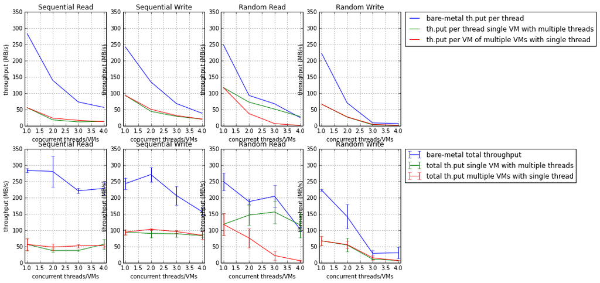

```python
x_axis = [1,2,3,4]

plt.subplot(241)
plt.plot(x_axis, bwsrbf, x_axis, bwsrsvm, x_axis, bwsrmvm)
plt.axis([0.9, 4.1, 0, 350])
plt.grid(True)
plt.title('Sequential Read')
pylab.xlabel('concurrent threads/VMs')
pylab.ylabel('throughput (MB/s)')

plt.subplot(242)
plt.plot(x_axis, bwswbf, x_axis, bwswsvm, x_axis, bwswmvm)
plt.axis([0.9, 4.1, 0, 350])
plt.grid(True)
plt.title('Sequential Write')
pylab.xlabel('concurrent threads/VMs')
pylab.ylabel('throughput (MB/s)')

plt.subplot(243)
plt.plot(x_axis, bwrrbf, x_axis, bwrrsvm, x_axis, bwrrmvm)
plt.axis([0.9, 4.1, 0, 350])
plt.grid(True)
plt.title('Random Read')
pylab.xlabel('concurrent threads/VMs')
pylab.ylabel('throughput (MB/s)')

plt.subplot(244)
plt.plot(x_axis, bwrwbf, label = 'bare-metal th.put per thread')
plt.plot(x_axis, bwrwsvm, label = 'th.put per thread single VM with multiple threads')
plt.plot(x_axis, bwrwmvm, label = 'th.put per VM of multiple VMs with single thread')
plt.axis([0.9, 4.1, 0, 350])
plt.grid(True)
plt.title('Random Write')
plt.legend(bbox_to_anchor=(1.05, 1), loc=2, borderaxespad=0.)
pylab.xlabel('concurrent threads/VMs')
pylab.ylabel('throughput (MB/s)')

plt.subplot(245)
plt.errorbar(x_axis, aggbwsrbf, ciaggbwsrbf)
plt.errorbar(x_axis, aggbwsrsvm, ciaggbwsrsvm)
plt.errorbar(x_axis, aggbwsrmvm, ciaggbwsrmvm)
plt.axis([0.9, 4.1, 0, 350])
plt.grid(True)
plt.title('Sequential Read')
pylab.xlabel('concurrent threads/VMs')
pylab.ylabel('throughput (MB/s)')

plt.subplot(246)
plt.errorbar(x_axis, aggbwswbf, ciaggbwswbf)
plt.errorbar(x_axis, aggbwswsvm, ciaggbwswsvm)
plt.errorbar(x_axis, aggbwswmvm, ciaggbwswmvm)
plt.axis([0.9, 4.1, 0, 350])
plt.grid(True)
plt.title('Sequential Write')
pylab.xlabel('concurrent threads/VMs')
pylab.ylabel('throughput (MB/s)')

plt.subplot(247)
plt.errorbar(x_axis, aggbwrrbf, ciaggbwrrbf)
plt.errorbar(x_axis, aggbwrrsvm, ciaggbwrrsvm)
plt.errorbar(x_axis, aggbwrrmvm, ciaggbwrrmvm)
plt.axis([0.9, 4.1, 0, 350])
plt.grid(True)
plt.title('Random Read')
pylab.xlabel('concurrent threads/VMs')
pylab.ylabel('throughput (MB/s)')

plt.subplot(248)
plt.errorbar(x_axis, aggbwrwbf, ciaggbwrwbf, label = 'bare-metal total throughput')
plt.errorbar(x_axis, aggbwrwsvm, ciaggbwrwsvm, label = 'total th.put single VM with multiple threads')
plt.errorbar(x_axis, aggbwrwmvm, ciaggbwrwmvm, label = 'total th.put multiple VMs with single thread')
plt.axis([0.9, 4.1, 0, 350])
plt.grid(True)
plt.title('Random Write')
plt.legend(bbox_to_anchor=(1.05, 1), loc=2, borderaxespad=0.)
pylab.xlabel('concurrent threads/VMs')
pylab.ylabel('throughput (MB/s)')
```

The storage review suggest that our hard drives having peak speed at 115 MB/s for sequential read/write and 57 MB/s for random read/write with the test of 4K block size. However, we got triple the rate!?!?!? This transfer rate is like a modern Solid State Drive (SSD), not an hard drive with only 7200rpm.

http://www.storagereview.com/seagate_constellation2_and_constellation_es2_hard_drive_review

One explanation for this maybe because of the IO depth that they are using. When we run the same test with I/O depth at 1 with native asynchonous Linux I/O library, we also got around this value. Or maybe the program that we use got a bug when reporting.

The four top figures represent the avarage throughput of each thread on one host, while the bottom ones represent the aggregated throughput on one host. If the value is correct, we can easily see that thread inside VM performance is really low. For bare-metal platform, it's expectedly to see the performance of sequential write is little bit lower than the performance of sequential read. However, what we got in the performance of VM platform is the opposite. Sequential write is higher about 20-30 in compare with sequential read. We also see the weird behavior on the three platforms in case of random read. The average achieved bandwidth of the thread is very low when the number of parallel threads increase over 3. Some of the threads have very low throughput while few others still get high throughput. It can be very easy to recognize this in Jain Fairness figures. For the case of single VMs with multiple threads, we cannot believe that it has higher througput in compare with the bare-metal. For case of random write, the throughput is also very low when the number of parellel thread is over 3.

## Throughput normalization

*(throughput of bare-metal is used as baseline)*

```python
from __future__ import division # floating point division in Py2x
# for throughput per thread/VM
nml_bwsrbf = [x/y for x,y in zip(bwsrbf,bwsrbf)]
nml_bwswbf = [x/y for x,y in zip(bwswbf,bwswbf)]
nml_bwrrbf = [x/y for x,y in zip(bwrrbf,bwrrbf)]
nml_bwrwbf = [x/y for x,y in zip(bwrwbf,bwrwbf)]
nml_bwsrsvm = [x/y for x,y in zip(bwsrsvm,bwsrbf)]
nml_bwswsvm = [x/y for x,y in zip(bwswsvm,bwswbf)]
nml_bwrrsvm = [x/y for x,y in zip(bwrrsvm,bwrrbf)]
nml_bwrwsvm = [x/y for x,y in zip(bwrwsvm,bwrwbf)]
nml_bwsrmvm = [x/y for x,y in zip(bwsrmvm,bwsrbf)]
nml_bwswmvm = [x/y for x,y in zip(bwswmvm,bwswbf)]
nml_bwrrmvm = [x/y for x,y in zip(bwrrmvm,bwrrbf)]
nml_bwrwmvm = [x/y for x,y in zip(bwrwmvm,bwrwbf)]
# for aggregated throughput
nml_aggbwsrbf = [x/y for x,y in zip(aggbwsrbf,aggbwsrbf)]
nml_aggbwswbf = [x/y for x,y in zip(aggbwswbf,aggbwswbf)]
nml_aggbwrrbf = [x/y for x,y in zip(aggbwrrbf,aggbwrrbf)]
nml_aggbwrwbf = [x/y for x,y in zip(aggbwrwbf,aggbwrwbf)]
nml_aggbwsrsvm = [x/y for x,y in zip(aggbwsrsvm,aggbwsrbf)]
nml_aggbwswsvm = [x/y for x,y in zip(aggbwswsvm,aggbwswbf)]
nml_aggbwrrsvm = [x/y for x,y in zip(aggbwrrsvm,aggbwrrbf)]
nml_aggbwrwsvm = [x/y for x,y in zip(aggbwrwsvm,aggbwrwbf)]
nml_aggbwsrmvm = [x/y for x,y in zip(aggbwsrmvm,aggbwsrbf)]
nml_aggbwswmvm = [x/y for x,y in zip(aggbwswmvm,aggbwswbf)]
nml_aggbwrrmvm = [x/y for x,y in zip(aggbwrrmvm,aggbwrrbf)]
nml_aggbwrwmvm = [x/y for x,y in zip(aggbwrwmvm,aggbwrwbf)]
```

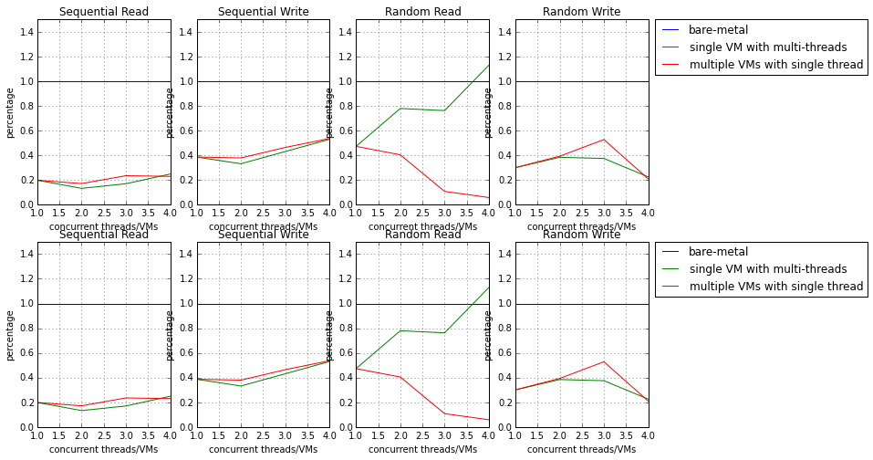

```python
x_axis = [1,2,3,4]

plt.subplot(241)
plt.plot(x_axis, nml_bwsrbf, x_axis, nml_bwsrsvm, x_axis, nml_bwsrmvm)
plt.axis([1, 4, 0, 1.5])
plt.grid(True)
plt.title('Sequential Read')
pylab.xlabel('concurrent threads/VMs')
pylab.ylabel('percentage')

plt.subplot(242)
plt.plot(x_axis, nml_bwswbf, x_axis, nml_bwswsvm, x_axis, nml_bwswmvm)
plt.axis([1, 4, 0, 1.5])
plt.grid(True)
plt.title('Sequential Write')
pylab.xlabel('concurrent threads/VMs')
pylab.ylabel('percentage')

plt.subplot(243)
plt.plot(x_axis, nml_bwrrbf, x_axis, nml_bwrrsvm, x_axis, nml_bwrrmvm)
plt.axis([1, 4, 0, 1.5])
plt.grid(True)
plt.title('Random Read')
pylab.xlabel('concurrent threads/VMs')
pylab.ylabel('percentage')

plt.subplot(244)
plt.plot(x_axis, nml_bwrwbf, label = 'bare-metal')
plt.plot(x_axis, nml_bwrwsvm, label = 'single VM with multi-threads')
plt.plot(x_axis, nml_bwrwmvm, label = 'multiple VMs with single thread')
plt.axis([1, 4, 0, 1.5])
plt.grid(True)
plt.title('Random Write')
plt.legend(bbox_to_anchor=(1.05, 1), loc=2, borderaxespad=0.)
pylab.xlabel('concurrent threads/VMs')
pylab.ylabel('percentage')

plt.subplot(245)
plt.plot(x_axis, nml_aggbwsrbf, x_axis, nml_aggbwsrsvm, x_axis, nml_aggbwsrmvm)
plt.axis([1, 4, 0, 1.5])
plt.grid(True)
plt.title('Sequential Read')
pylab.xlabel('concurrent threads/VMs')
pylab.ylabel('percentage')

plt.subplot(246)
plt.plot(x_axis, nml_aggbwswbf, x_axis, nml_aggbwswsvm, x_axis, nml_aggbwswmvm)
plt.axis([1, 4, 0, 1.5])
plt.grid(True)
plt.title('Sequential Write')
pylab.xlabel('concurrent threads/VMs')
pylab.ylabel('percentage')

plt.subplot(247)
plt.plot(x_axis, nml_aggbwrrbf, x_axis, nml_aggbwrrsvm, x_axis, nml_aggbwrrmvm)
plt.axis([1, 4, 0, 1.5])
plt.grid(True)
plt.title('Random Read')
pylab.xlabel('concurrent threads/VMs')
pylab.ylabel('percentage')

plt.subplot(248)
plt.plot(x_axis, nml_aggbwrwbf, label = 'bare-metal')
plt.plot(x_axis, nml_aggbwrwsvm, label = 'single VM with multi-threads')
plt.plot(x_axis, nml_aggbwrwmvm, label = 'multiple VMs with single thread')
plt.axis([1, 4, 0, 1.5])
plt.grid(True)
plt.title('Random Write')
plt.legend(bbox_to_anchor=(1.05, 1), loc=2, borderaxespad=0.)
pylab.xlabel('concurrent threads/VMs')
pylab.ylabel('percentage')
```

In other see the overhead of the baremetal, we will look at the normalization of the aggregated throughput of the three platform: bare-metal, single VM with multiple threads, and multiple VMs with single thread. We set the throughput of bare-metal as the base and compare with the VM ones. For sequential read, throughput of VM cases only achieves 20 per cent of the bare-metal. It increases to 40-50 per cent in case of sequential write due to the lost in throughput of bare-metal and the gain in throughput of VM cases. It's not unexpected to see the same weird behavior in case of random read. In conclusion,the throughput that we got from the test has raised several questions that we need to answer to have a better understanding on the disk performance of the virtualized systems: why does VM gets too low performance? what make the sequential write test of VM getting better performance in compare with bare metal? Why is there such weird behavior in case of random read? To answer these, we will look into other metrics of the experiments: Jain Fairness Index, CPU utilisation, Disk Utilization, Context Switching, and number IO per second.

## Jain Fairness Index

```python
jfidataofhost = dtdata[selectedhost] # Use only data on 1 host, changing host by redefining range
jfi = jfidataofhost.T.sum()**2/jfidataofhost.T.count()/(jfidataofhost**2).T.sum() #Calculate Jair Fairness Index for each test
jfigrouped = jfi.groupby(level=0)
jfiavg = jfigrouped.mean() # Calculate JFI average from 5 tests

# for plotting confident interval
# jfistd = jfigrouped.std() # Standard Deviation
cijfi = jfigrouped.aggregate(lambda x: np.std(x) / np.sqrt(x.count()) * 1.96) # Confident interval of 95%

# prepare for plotting
jfisrbf = jfiavg.filter(regex="^SRBFTH").tolist()
jfiswbf = jfiavg.filter(regex="^SWBFTH").tolist()
jfirrbf = jfiavg.filter(regex="^RRBFTH").tolist()
jfirwbf = jfiavg.filter(regex="^RWBFTH").tolist()
jfisrsvm = jfiavg.filter(regex="^SR1VMTH").tolist()
jfiswsvm = jfiavg.filter(regex="^SW1VMTH").tolist()
jfirrsvm = jfiavg.filter(regex="^RR1VMTH").tolist()
jfirwsvm = jfiavg.filter(regex="^RW1VMTH").tolist()
jfisrmvm = jfiavg.filter(regex="^SR[1-4]VMTH1").tolist()
jfiswmvm = jfiavg.filter(regex="^SW[1-4]VMTH1").tolist()
jfirrmvm = jfiavg.filter(regex="^RR[1-4]VMTH1").tolist()
jfirwmvm = jfiavg.filter(regex="^RW[1-4]VMTH1").tolist()

cijfisrbf = cijfi.filter(regex="^SRBFTH").tolist()
cijfiswbf = cijfi.filter(regex="^SWBFTH").tolist()
cijfirrbf = cijfi.filter(regex="^RRBFTH").tolist()
cijfirwbf = cijfi.filter(regex="^RWBFTH").tolist()
cijfisrsvm = cijfi.filter(regex="^SR1VMTH").tolist()
cijfiswsvm = cijfi.filter(regex="^SW1VMTH").tolist()
cijfirrsvm = cijfi.filter(regex="^RR1VMTH").tolist()
cijfirwsvm = cijfi.filter(regex="^RW1VMTH").tolist()
cijfisrmvm = cijfi.filter(regex="^SR[1-4]VMTH1").tolist()
cijfiswmvm = cijfi.filter(regex="^SW[1-4]VMTH1").tolist()
cijfirrmvm = cijfi.filter(regex="^RR[1-4]VMTH1").tolist()
cijfirwmvm = cijfi.filter(regex="^RW[1-4]VMTH1").tolist()
```

```
 <a list of 4 Text xticklabel objects>)
```

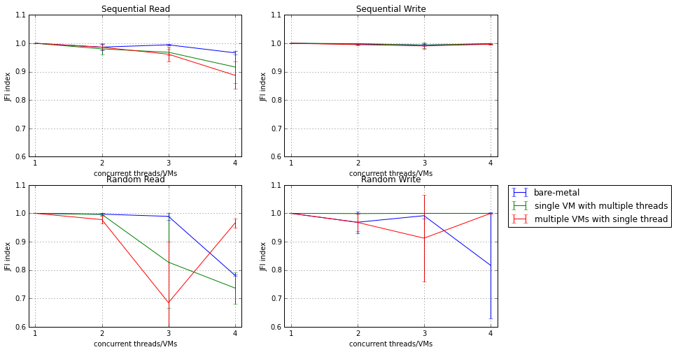

```python
x_axis = [1,2,3,4]

plt.subplot(221)
plt.errorbar(x_axis, jfisrbf, cijfisrbf)
plt.errorbar(x_axis, jfisrsvm, cijfisrsvm)
plt.errorbar(x_axis, jfisrmvm, cijfisrmvm)
plt.axis([0.9, 4.1, 0.6, 1.1])
plt.grid(True)
plt.title('Sequential Read')
plt.xlabel('concurrent threads/VMs')
plt.ylabel('JFI index')
plt.xticks(x_axis)

plt.subplot(222)
plt.errorbar(x_axis, jfiswbf, cijfiswbf)
plt.errorbar(x_axis, jfiswsvm, cijfiswsvm)
plt.errorbar(x_axis, jfiswmvm, cijfiswmvm)
plt.axis([0.9, 4.1, 0.6, 1.1])
plt.grid(True)
plt.title('Sequential Write')
plt.xlabel('concurrent threads/VMs')
plt.ylabel('JFI index')
plt.xticks(x_axis)

plt.subplot(223)
plt.errorbar(x_axis, jfirrbf, cijfirrbf)
plt.errorbar(x_axis, jfirrsvm, cijfirrsvm)
plt.errorbar(x_axis, jfirrmvm, cijfirrmvm)
plt.axis([0.9, 4.1, 0.6, 1.1])
plt.grid(True)
plt.title('Random Read')
plt.xlabel('concurrent threads/VMs')
plt.ylabel('JFI index')
plt.xticks(x_axis)

plt.subplot(224)
# plt.plot(x_axis, jfirwbf, label = 'bare-metal')
plt.errorbar(x_axis, jfirwbf, cijfirwbf, label = 'bare-metal')
plt.errorbar(x_axis, jfirwsvm, cijfirwsvm, label = 'single VM with multiple threads')
plt.errorbar(x_axis, jfirwmvm, cijfirwmvm, label = 'multiple VMs with single thread')
plt.axis([0.9, 4.1, 0.6, 1.1])
plt.grid(True)
plt.title('Random Write')
plt.legend(bbox_to_anchor=(1.05, 1), loc=2, borderaxespad=0.)
plt.xlabel('concurrent threads/VMs')
plt.ylabel('JFI index')
plt.xticks(x_axis)
```

Jain Fairness Index (JFI) has a range from 0 to 1 which indicates the level of fairness between concurrent threads. If the threads receive equal partition of bandwidth, we would achieve index of 1. If only k of n flows receive equal bandwidth (and others get none), index is k/n. In the worst case, JFI has the index of 0. We plot some figures of JFI for the three platforms with confident interval of 95%. The figures show that threads have very equal throughput except the case of Random Read and Random Write. We notice the reader that the figures show value of JFI from 0.6 to 1.1 for a clear view on the JFI of the system.

## CPU Utilization

For CPU utilization, FIO relies on *getrusage()*. *Getrusage()* returns resource usage statistics for the calling thread. The resource usages are returned in the structure pointed to by usage, which has the following form:

```
struct rusage {
    struct timeval ru_utime; /* user CPU time used */
    struct timeval ru_stime; /* system CPU time used */
    ...
    long   ru_minflt;        /* page reclaims (soft page faults) */
    long   ru_majflt;        /* page faults (hard page faults) */
    long   ru_nswap;         /* swaps */
    ...
    long   ru_nvcsw;         /* voluntary context switches */
    long   ru_nivcsw;        /* involuntary context switches */
};
```

and contains inside the *struct*:

- *ru_utime*: This is the total amount of time spent executing in user mode, expressed in a *timeval* structure (seconds plus microseconds).
- *ru_stime*: This is the total amount of time spent executing in kernel mode, expressed in a *timeval* structure (seconds plus microseconds).
- *ru_nvcsw*: The number of times a context switch resulted due to a process voluntarily giving up the processor before its time slice was completed (usually to await availability of a resource).
- *ru_nivcsw*: The number of times a context switch resulted due to a higher priority process becoming runnable or because the current process exceeded its time slice.

FIO reports the CPU utilization for each thread by (*user_time/total_run_time*) and (*system_time/total_run_time*), where:

```
    runtime = ts->total_run_time;
    if (runtime) {
        double runt = (double) runtime;

        usr_cpu = (double) ts->usr_time * 100 / runt;
        sys_cpu = (double) ts->sys_time * 100 / runt;
    } else {
        usr_cpu = 0;
        sys_cpu = 0;
    }
```

In this report, we especially forcus on the the serving time (the time that thread actually uses the CPU) and the waiting time (the time that thread has to wait for the other when its slice is up).

```python
# Remove percentage symbol in csv file first
!sed -i 's/%//g' data/dtCpuUsageUserSpace.csv
!sed -i 's/%//g' data/dtCpuUsageSystemSpace.csv
```

```python
# Load time spending in user space
cpuusresult = pd.read_csv('data/dtCpuUsageUserSpace.csv', delimiter=' ', header=None)
cpuusdata = cpuusresult[range(1,21)]
cpuusindex = cpuusresult[0]
cpuusdata.index = cpuusindex.str.replace('T1|T2|T3|T4|T5', '',case=False)
# Load time spending in kernel space
cpuksresult = pd.read_csv('data/dtCpuUsageSystemSpace.csv', delimiter=' ', header=None)
cpuksdata = cpuksresult[range(1,21)]
cpuksindex = cpuksresult[0]
cpuksdata.index = cpuksindex.str.replace('T1|T2|T3|T4|T5', '',case=False)
# Load total runtime of thread
threadruntimeresult = pd.read_csv('data/dtRunTimeMs.csv', delimiter=' ', header=None)
threadruntimedata = threadruntimeresult[range(1,21)]
threadruntimeindex = threadruntimeresult[0]
threadruntimedata.index = threadruntimeindex.str.replace('T1|T2|T3|T4|T5', '',case=False)
```

```python
# Calculate duration that thread utilise the CPU
# Real CPU utilisation duration (ms) = (user time (%) + system time (%)) * runtime (ms)
totalcpupercentage = cpuusdata + cpuksdata
totalcputime = totalcpupercentage.mul(threadruntimedata,1) / 100
```

```python
totalcputimehostdata = totalcputime[selectedhost]
totalcputimehostin1test = totalcputimehostdata.T.sum() # Sum of CPU serving time in one test
totalcputime5testsgrouped = totalcputimehostin1test.groupby(level=0)
totalcputimehostavgin5tests = totalcputime5testsgrouped.mean() # Mean of each thread/VM on 5 tests
citct = totalcputime5testsgrouped.aggregate(lambda x: np.std(x) / np.sqrt(x.count()) * 1.96) # Confident interval of 95%
```

```python
threadruntimehostdata = threadruntimedata[selectedhost]
threadruntimehostin1test = threadruntimehostdata.T.sum() # Sum of thread running time in one test
threadruntime5testsgrouped = threadruntimehostin1test.groupby(level=0)
threadruntimehostavgin5tests = threadruntime5testsgrouped.mean() # Mean of each thread/VM on 5 tests
citrt = threadruntime5testsgrouped.aggregate(lambda x: np.std(x) / np.sqrt(x.count()) * 1.96) # Confident interval of 95%
```

```python
# CPU serving time
tctsrbf = totalcputimehostavgin5tests.filter(regex="^SRBFTH").tolist()
tctswbf = totalcputimehostavgin5tests.filter(regex="^SWBFTH").tolist()
tctrrbf = totalcputimehostavgin5tests.filter(regex="^RRBFTH").tolist()
tctrwbf = totalcputimehostavgin5tests.filter(regex="^RWBFTH").tolist()
tctsrsvm = totalcputimehostavgin5tests.filter(regex="^SR1VMTH").tolist()
tctswsvm = totalcputimehostavgin5tests.filter(regex="^SW1VMTH").tolist()
tctrrsvm = totalcputimehostavgin5tests.filter(regex="^RR1VMTH").tolist()
tctrwsvm = totalcputimehostavgin5tests.filter(regex="^RW1VMTH").tolist()
tctsrmvm = totalcputimehostavgin5tests.filter(regex="^SR[1-4]VMTH1").tolist()
tctswmvm = totalcputimehostavgin5tests.filter(regex="^SW[1-4]VMTH1").tolist()
tctrrmvm = totalcputimehostavgin5tests.filter(regex="^RR[1-4]VMTH1").tolist()
tctrwmvm = totalcputimehostavgin5tests.filter(regex="^RW[1-4]VMTH1").tolist()

# Confident interval
citctsrbf = citct.filter(regex="^SRBFTH").tolist()
citctswbf = citct.filter(regex="^SWBFTH").tolist()
citctrrbf = citct.filter(regex="^RRBFTH").tolist()
citctrwbf = citct.filter(regex="^RWBFTH").tolist()
citctsrsvm = citct.filter(regex="^SR1VMTH").tolist()
citctswsvm = citct.filter(regex="^SW1VMTH").tolist()
citctrrsvm = citct.filter(regex="^RR1VMTH").tolist()
citctrwsvm = citct.filter(regex="^RW1VMTH").tolist()
citctsrmvm = citct.filter(regex="^SR[1-4]VMTH1").tolist()
citctswmvm = citct.filter(regex="^SW[1-4]VMTH1").tolist()
citctrrmvm = citct.filter(regex="^RR[1-4]VMTH1").tolist()
citctrwmvm = citct.filter(regex="^RW[1-4]VMTH1").tolist()

# Thread running time
trtsrbf = threadruntimehostavgin5tests.filter(regex="^SRBFTH").tolist()
trtswbf = threadruntimehostavgin5tests.filter(regex="^SWBFTH").tolist()
trtrrbf = threadruntimehostavgin5tests.filter(regex="^RRBFTH").tolist()
trtrwbf = threadruntimehostavgin5tests.filter(regex="^RWBFTH").tolist()
trtsrsvm = threadruntimehostavgin5tests.filter(regex="^SR1VMTH").tolist()
trtswsvm = threadruntimehostavgin5tests.filter(regex="^SW1VMTH").tolist()
trtrrsvm = threadruntimehostavgin5tests.filter(regex="^RR1VMTH").tolist()
trtrwsvm = threadruntimehostavgin5tests.filter(regex="^RW1VMTH").tolist()
trtsrmvm = threadruntimehostavgin5tests.filter(regex="^SR[1-4]VMTH1").tolist()
trtswmvm = threadruntimehostavgin5tests.filter(regex="^SW[1-4]VMTH1").tolist()
trtrrmvm = threadruntimehostavgin5tests.filter(regex="^RR[1-4]VMTH1").tolist()
trtrwmvm = threadruntimehostavgin5tests.filter(regex="^RW[1-4]VMTH1").tolist()

# Confident interval
citrtsrbf = citrt.filter(regex="^SRBFTH").tolist()
citrtswbf = citrt.filter(regex="^SWBFTH").tolist()
citrtrrbf = citrt.filter(regex="^RRBFTH").tolist()
citrtrwbf = citrt.filter(regex="^RWBFTH").tolist()
citrtsrsvm = citrt.filter(regex="^SR1VMTH").tolist()
citrtswsvm = citct.filter(regex="^SW1VMTH").tolist()
citrtrrsvm = citrt.filter(regex="^RR1VMTH").tolist()
citrtrwsvm = citrt.filter(regex="^RW1VMTH").tolist()
citrtsrmvm = citrt.filter(regex="^SR[1-4]VMTH1").tolist()
citrtswmvm = citrt.filter(regex="^SW[1-4]VMTH1").tolist()
citrtrrmvm = citrt.filter(regex="^RR[1-4]VMTH1").tolist()
citrtrwmvm = citrt.filter(regex="^RW[1-4]VMTH1").tolist()
```

```
 <a list of 4 Text xticklabel objects>)
```

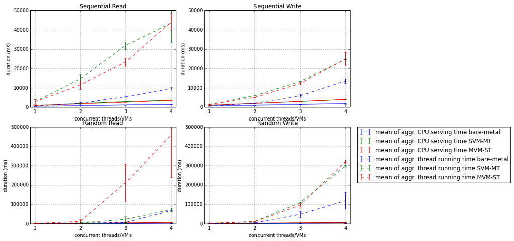

```python
x_axis = [1,2,3,4]

plt.subplot(221)
plt.errorbar(x_axis, tctsrbf, citctsrbf, color="blue")
plt.errorbar(x_axis, tctsrsvm, citctsrsvm, color="green")
plt.errorbar(x_axis, tctsrmvm, citctsrmvm, color="red")
plt.errorbar(x_axis, trtsrbf, citrtsrbf, ls="dashed", color="blue")
plt.errorbar(x_axis, trtsrsvm, citrtsrsvm, ls="dashed", color="green")
plt.errorbar(x_axis, trtsrmvm, citrtsrmvm, ls="dashed", color="red")
plt.axis([0.9, 4.1, 0, 50000])
plt.grid(True)
plt.title('Sequential Read')
plt.xlabel('concurrent threads/VMs')
plt.ylabel('duration (ms)')
plt.xticks(x_axis)

plt.subplot(222)
plt.errorbar(x_axis, tctswbf, citctswbf, color="blue")
plt.errorbar(x_axis, tctswsvm, citctswsvm, color="green")
plt.errorbar(x_axis, tctswmvm, citctswmvm, color="red")
plt.errorbar(x_axis, trtswbf, citrtswbf, ls="dashed", color="blue")
plt.errorbar(x_axis, trtswsvm, citrtswsvm, ls="dashed", color="green")
plt.errorbar(x_axis, trtswmvm, citrtswmvm, ls="dashed", color="red")
plt.axis([0.9, 4.1, 0, 50000])
plt.grid(True)
plt.title('Sequential Write')
plt.xlabel('concurrent threads/VMs')
plt.ylabel('duration (ms)')
plt.xticks(x_axis)

plt.subplot(223)
plt.errorbar(x_axis, tctrrbf, citctrrbf, color="blue")
plt.errorbar(x_axis, tctrrsvm, citctrrsvm, color="green")
plt.errorbar(x_axis, tctrrmvm, citctrrmvm, color="red")
plt.errorbar(x_axis, trtrrbf, citrtrrbf, ls="dashed", color="blue")
plt.errorbar(x_axis, trtrrsvm, citrtrrsvm, ls="dashed", color="green")
plt.errorbar(x_axis, trtrrmvm, citrtrrmvm, ls="dashed", color="red")
plt.axis([0.9, 4.1, 0, 500000])
plt.grid(True)
plt.title('Random Read')
plt.xlabel('concurrent threads/VMs')
plt.ylabel('duration (ms)')
plt.xticks(x_axis)

plt.subplot(224)
plt.errorbar(x_axis, tctrwbf, citctrwbf, color="blue", label = 'mean of aggr. CPU serving time bare-metal')
plt.errorbar(x_axis, tctrwsvm, citctrwsvm, color="green", label = 'mean of aggr. CPU serving time SVM-MT')
plt.errorbar(x_axis, tctrwmvm, citctrwmvm, color="red", label = 'mean of aggr. CPU serving time MVM-ST')
plt.errorbar(x_axis, trtrwbf, citrtrwbf, ls="dashed", color="blue", label = 'mean of aggr. thread running time bare-metal')
plt.errorbar(x_axis, trtrwsvm, citrtrwsvm, ls="dashed", color="green", label = 'mean of aggr. thread running time SVM-MT')
plt.errorbar(x_axis, trtrwmvm, citrtrwmvm, ls="dashed", color="red", label = 'mean of aggr. thread running time MVM-ST')
plt.axis([0.9, 4.1, 0, 500000])
plt.grid(True)
plt.title('Random Write')
plt.legend(bbox_to_anchor=(1.05, 1), loc=2, borderaxespad=0.)
plt.xlabel('concurrent threads/VMs')
plt.ylabel('duration (ms)')
plt.xticks(x_axis)
```

The idea to use this figure is that we can see the increasing overhead when multiple threads/VMs try to compete for the bandwidth by observing the time that threads/VMs waiting for their turn.

```
 <a list of 4 Text xticklabel objects>)
```

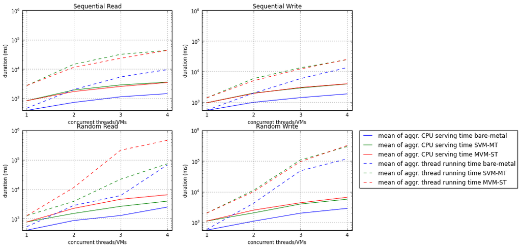

```python
x_axis = [1,2,3,4]

plt.subplot(221)
plt.semilogy(x_axis, tctsrbf, color="blue")
plt.semilogy(x_axis, tctsrsvm, color="green")
plt.semilogy(x_axis, tctsrmvm, color="red")
plt.semilogy(x_axis, trtsrbf, ls="dashed", color="blue")
plt.semilogy(x_axis, trtsrsvm, ls="dashed", color="green")
plt.semilogy(x_axis, trtsrmvm, ls="dashed", color="red")
plt.axis([0.9, 4.1, 0, 1000000])
plt.grid(True)
plt.title('Sequential Read')
plt.xlabel('concurrent threads/VMs')
plt.ylabel('duration (ms)')
plt.xticks(x_axis)

plt.subplot(222)
plt.semilogy(x_axis, tctswbf, color="blue")
plt.semilogy(x_axis, tctswsvm, color="green")
plt.semilogy(x_axis, tctswmvm, color="red")
plt.semilogy(x_axis, trtswbf, ls="dashed", color="blue")
plt.semilogy(x_axis, trtswsvm, ls="dashed", color="green")
plt.semilogy(x_axis, trtswmvm, ls="dashed", color="red")
plt.axis([0.9, 4.1, 0, 1000000])
plt.grid(True)
plt.title('Sequential Write')
plt.xlabel('concurrent threads/VMs')
plt.ylabel('duration (ms)')
plt.xticks(x_axis)

plt.subplot(223)
plt.semilogy(x_axis, tctrrbf, color="blue")
plt.semilogy(x_axis, tctrrsvm, color="green")
plt.semilogy(x_axis, tctrrmvm, color="red")
plt.semilogy(x_axis, trtrrbf, ls="dashed", color="blue")
plt.semilogy(x_axis, trtrrsvm, ls="dashed", color="green")
plt.semilogy(x_axis, trtrrmvm, ls="dashed", color="red")
plt.axis([0.9, 4.1, 0, 1000000])
plt.grid(True)
plt.title('Random Read')
plt.xlabel('concurrent threads/VMs')
plt.ylabel('duration (ms)')
plt.xticks(x_axis)

plt.subplot(224)
plt.semilogy(x_axis, tctrwbf, color="blue", label = 'mean of aggr. CPU serving time bare-metal')
plt.semilogy(x_axis, tctrwsvm, color="green", label = 'mean of aggr. CPU serving time SVM-MT')
plt.semilogy(x_axis, tctrwmvm, color="red", label = 'mean of aggr. CPU serving time MVM-ST')
plt.semilogy(x_axis, trtrwbf, ls="dashed", color="blue", label = 'mean of aggr. thread running time bare-metal')
plt.semilogy(x_axis, trtrwsvm, ls="dashed", color="green", label = 'mean of aggr. thread running time SVM-MT')
plt.semilogy(x_axis, trtrwmvm, ls="dashed", color="red", label = 'mean of aggr. thread running time MVM-ST')
plt.axis([0.9, 4.1, 0, 1000000])
plt.grid(True)
plt.title('Random Write')
plt.legend(bbox_to_anchor=(1.05, 1), loc=2, borderaxespad=0.)
plt.xlabel('concurrent threads/VMs')
plt.ylabel('duration (ms)')
plt.xticks(x_axis)
```

The figures suggest that for the same amount of data, the threads inside VMs occupied the CPU more time than the bare-metal to accomplish the tasks. There is not much different between the two virtualized scenarios: Single VM with multiple threads and multiple VM with single thread. CPU spending time is a very important metric since it represent how well the process use the allocated CPU slot. For the same amout of work unit, threads inside VM spend double the time that it may use if it is inside a bare-metal environment.

These figure also lack of the disk utilisation. When disk utilisation is the bottleneck, the thread running time and CPU spending time will also increase. In later experiment, we will extract also the disk utilisation to see how it affect on CPU spending time.

```
 <a list of 4 Text xticklabel objects>)
```

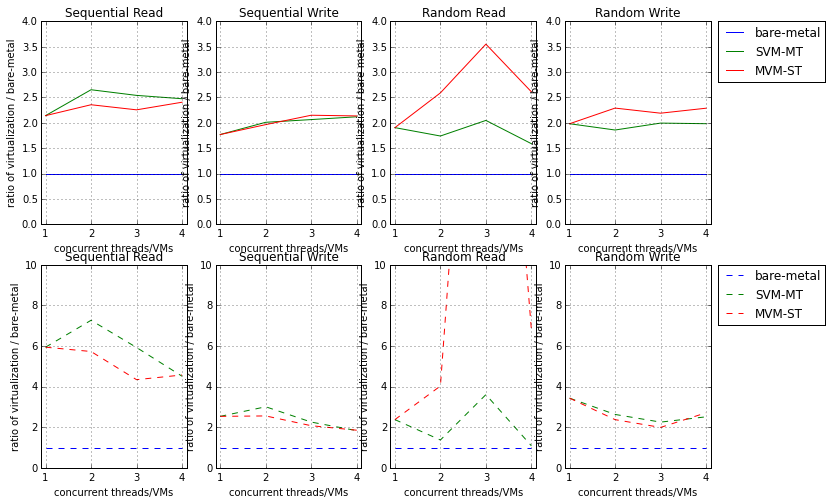

```python
# for throughput per thread/VM
nml_tctsrbf = [x/y for x,y in zip(tctsrbf,tctsrbf)]
nml_tctswbf = [x/y for x,y in zip(tctswbf,tctswbf)]
nml_tctrrbf = [x/y for x,y in zip(tctrrbf,tctrrbf)]
nml_tctrwbf = [x/y for x,y in zip(tctrwbf,tctrwbf)]
nml_tctsrsvm = [x/y for x,y in zip(tctsrsvm,tctsrbf)]
nml_tctswsvm = [x/y for x,y in zip(tctswsvm,tctswbf)]
nml_tctrrsvm = [x/y for x,y in zip(tctrrsvm,tctrrbf)]
nml_tctrwsvm = [x/y for x,y in zip(tctrwsvm,tctrwbf)]
nml_tctsrmvm = [x/y for x,y in zip(tctsrmvm,tctsrbf)]
nml_tctswmvm = [x/y for x,y in zip(tctswmvm,tctswbf)]
nml_tctrrmvm = [x/y for x,y in zip(tctrrmvm,tctrrbf)]
nml_tctrwmvm = [x/y for x,y in zip(tctrwmvm,tctrwbf)]

# for throughput per thread/VM
nml_trtsrbf = [x/y for x,y in zip(trtsrbf,trtsrbf)]
nml_trtswbf = [x/y for x,y in zip(trtswbf,trtswbf)]
nml_trtrrbf = [x/y for x,y in zip(trtrrbf,trtrrbf)]
nml_trtrwbf = [x/y for x,y in zip(trtrwbf,trtrwbf)]
nml_trtsrsvm = [x/y for x,y in zip(trtsrsvm,trtsrbf)]
nml_trtswsvm = [x/y for x,y in zip(trtswsvm,trtswbf)]
nml_trtrrsvm = [x/y for x,y in zip(trtrrsvm,trtrrbf)]
nml_trtrwsvm = [x/y for x,y in zip(trtrwsvm,trtrwbf)]
nml_trtsrmvm = [x/y for x,y in zip(trtsrmvm,trtsrbf)]
nml_trtswmvm = [x/y for x,y in zip(trtswmvm,trtswbf)]
nml_trtrrmvm = [x/y for x,y in zip(trtrrmvm,trtrrbf)]
nml_trtrwmvm = [x/y for x,y in zip(trtrwmvm,trtrwbf)]

plt.subplot(241)
plt.plot(x_axis, nml_tctsrbf, color="blue")
plt.plot(x_axis, nml_tctsrsvm, color="green")
plt.plot(x_axis, nml_tctsrmvm, color="red")
plt.axis([0.9, 4.1, 0, 4])
plt.grid(True)
plt.title('Sequential Read')
plt.xlabel('concurrent threads/VMs')
plt.ylabel('ratio of virtualization / bare-metal')
plt.xticks(x_axis)

plt.subplot(242)
plt.plot(x_axis, nml_tctswbf, color="blue")
plt.plot(x_axis, nml_tctswsvm, color="green")
plt.plot(x_axis, nml_tctswmvm, color="red")
plt.axis([0.9, 4.1, 0, 4])
plt.grid(True)
plt.title('Sequential Write')
plt.xlabel('concurrent threads/VMs')
plt.ylabel('ratio of virtualization / bare-metal')
plt.xticks(x_axis)

plt.subplot(243)
plt.plot(x_axis, nml_tctrrbf, color="blue")
plt.plot(x_axis, nml_tctrrsvm, color="green")
plt.plot(x_axis, nml_tctrrmvm, color="red")
plt.axis([0.9, 4.1, 0, 4])
plt.grid(True)
plt.title('Random Read')
plt.xlabel('concurrent threads/VMs')
plt.ylabel('ratio of virtualization / bare-metal')
plt.xticks(x_axis)

plt.subplot(244)
plt.plot(x_axis, nml_tctrwbf, color="blue", label = 'bare-metal')
plt.plot(x_axis, nml_tctrwsvm, color="green", label = 'SVM-MT')
plt.plot(x_axis, nml_tctrwmvm, color="red", label = 'MVM-ST')
plt.axis([0.9, 4.1, 0, 4])
plt.grid(True)
plt.title('Random Write')
plt.legend(bbox_to_anchor=(1.05, 1), loc=2, borderaxespad=0.)
plt.xlabel('concurrent threads/VMs')
plt.ylabel('ratio of virtualization / bare-metal')
plt.xticks(x_axis)

plt.subplot(245)
plt.plot(x_axis, nml_trtsrbf, ls="dashed", color="blue")
plt.plot(x_axis, nml_trtsrsvm, ls="dashed", color="green")
plt.plot(x_axis, nml_trtsrmvm, ls="dashed", color="red")
plt.axis([0.9, 4.1, 0, 10])
plt.grid(True)
plt.title('Sequential Read')
plt.xlabel('concurrent threads/VMs')
plt.ylabel('ratio of virtualization / bare-metal')
plt.xticks(x_axis)

plt.subplot(246)
plt.plot(x_axis, nml_trtswbf, ls="dashed", color="blue")
plt.plot(x_axis, nml_trtswsvm, ls="dashed", color="green")
plt.plot(x_axis, nml_trtswmvm, ls="dashed", color="red")
plt.axis([0.9, 4.1, 0, 10])
plt.grid(True)
plt.title('Sequential Write')
plt.xlabel('concurrent threads/VMs')
plt.ylabel('ratio of virtualization / bare-metal')
plt.xticks(x_axis)

plt.subplot(247)
plt.plot(x_axis, nml_trtrrbf, ls="dashed", color="blue")
plt.plot(x_axis, nml_trtrrsvm, ls="dashed", color="green")
plt.plot(x_axis, nml_trtrrmvm, ls="dashed", color="red")
plt.axis([0.9, 4.1, 0, 10])
plt.grid(True)
plt.title('Random Read')
plt.xlabel('concurrent threads/VMs')
plt.ylabel('ratio of virtualization / bare-metal')
plt.xticks(x_axis)

plt.subplot(248)
plt.plot(x_axis, nml_trtrwbf, ls="dashed", color="blue", label = 'bare-metal')
plt.plot(x_axis, nml_trtrwsvm, ls="dashed", color="green", label = 'SVM-MT')
plt.plot(x_axis, nml_trtrwmvm, ls="dashed", color="red", label = 'MVM-ST')
plt.axis([0.9, 4.1, 0, 10])
plt.grid(True)
plt.title('Random Write')
plt.legend(bbox_to_anchor=(1.05, 1), loc=2, borderaxespad=0.)
plt.xlabel('concurrent threads/VMs')
plt.ylabel('ratio of virtualization / bare-metal')
plt.xticks(x_axis)
```

## Context Switching

```python
cpucsresult = pd.read_csv('data/dtCpuUsageContextSwitch.csv', delimiter=' ', header=None)
cpucsdata = cpucsresult[range(1,21)]
cpucsindex = cpucsresult[0]
cpucsdata.index = cpucsindex.str.replace('T1|T2|T3|T4|T5', '',case=False)
```

```python
cpucshostdata = cpucsdata[selectedhost]
cpucshostavgin1test = cpucshostdata.T.mean() # Mean of CPU usage of each host in 1 test
cpucshostavgin5tests = cpucshostavgin1test.groupby(level=0).mean() # Mean of CPU usage of each host in 5 tests
```

```python
cpucssrbf = cpucshostavgin5tests.filter(regex="^SRBFTH").tolist()
cpucsswbf = cpucshostavgin5tests.filter(regex="^SWBFTH").tolist()
cpucsrrbf = cpucshostavgin5tests.filter(regex="^RRBFTH").tolist()
cpucsrwbf = cpucshostavgin5tests.filter(regex="^RWBFTH").tolist()
cpucssrsvm = cpucshostavgin5tests.filter(regex="^SR1VMTH").tolist()
cpucsswsvm = cpucshostavgin5tests.filter(regex="^SW1VMTH").tolist()
cpucsrrsvm = cpucshostavgin5tests.filter(regex="^RR1VMTH").tolist()
cpucsrwsvm = cpucshostavgin5tests.filter(regex="^RW1VMTH").tolist()
cpucssrmvm = cpucshostavgin5tests.filter(regex="^SR[1-4]VMTH1").tolist()
cpucsswmvm = cpucshostavgin5tests.filter(regex="^SW[1-4]VMTH1").tolist()
cpucsrrmvm = cpucshostavgin5tests.filter(regex="^RR[1-4]VMTH1").tolist()
cpucsrwmvm = cpucshostavgin5tests.filter(regex="^RW[1-4]VMTH1").tolist()
```

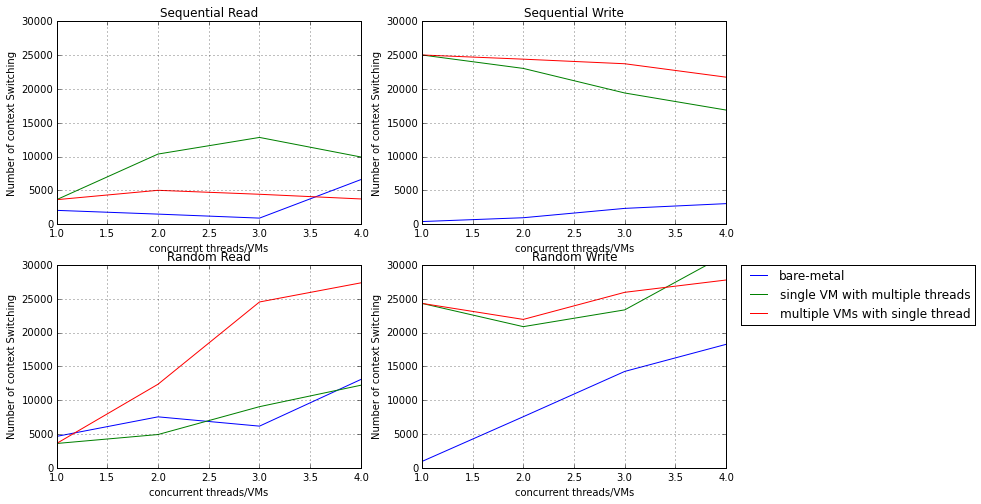

```python
x_axis = [1,2,3,4]

plt.subplot(221)
plt.plot(x_axis, cpucssrbf, x_axis, cpucssrsvm, x_axis, cpucssrmvm)
plt.axis([1, 4, 0, 30000])
plt.grid(True)
plt.title('Sequential Read')
pylab.xlabel('concurrent threads/VMs')
pylab.ylabel('Number of context Switching')

plt.subplot(222)
plt.plot(x_axis, cpucsswbf, x_axis, cpucsswsvm, x_axis, cpucsswmvm)
plt.axis([1, 4, 0, 30000])
plt.grid(True)
plt.title('Sequential Write')
pylab.xlabel('concurrent threads/VMs')
pylab.ylabel('Number of context Switching')

plt.subplot(223)
plt.plot(x_axis, cpucsrrbf, x_axis, cpucsrrsvm, x_axis, cpucsrrmvm)
plt.axis([1, 4, 0, 30000])
plt.grid(True)
plt.title('Random Read')
pylab.xlabel('concurrent threads/VMs')
pylab.ylabel('Number of context Switching')

plt.subplot(224)
plt.plot(x_axis, cpucsrwbf, label = 'bare-metal')
plt.plot(x_axis, cpucsrwsvm, label = 'single VM with multiple threads')
plt.plot(x_axis, cpucsrwmvm, label = 'multiple VMs with single thread')
plt.axis([1, 4, 0, 30000])
plt.grid(True)
plt.title('Random Write')
plt.legend(bbox_to_anchor=(1.05, 1), loc=2, borderaxespad=0.)
pylab.xlabel('concurrent threads/VMs')
pylab.ylabel('Number of context Switching')
```

Other related work have not discussed about context switching in virtualized environment. Since the most spending time task in the hard drive is seeking, or moving the actuator arm to the data location to read/write. The more context switching happens, the more seeking that actuator arm need to move. It will affect directly on the performance of VM.

## IOPS

```python
iopsresult = pd.read_csv('data/dtIOPS.csv', delimiter=' ', header=None)
iopsdata = iopsresult[range(1,21)]
iopsindex = iopsresult[0]
iopsdata.index = iopsindex.str.replace('T1|T2|T3|T4|T5', '',case=False)
```

```python
onehostdata = iopsdata[selectedhost]
```

```python
# To calculate the average throughput, we first calculate average throughput each thread has in one test, then again take the
# average of 5 tests
avgiopsin1test = onehostdata.T.mean() # Average throughput of each thread/VM in one test
avgiopsin5tests = avgiopsin1test.groupby(level=0).mean() # Average throughput of each thread/VM in 5 tests
```

```python
# Putting average throughput per thread/VM to vector before plotting
iopssrbf = avgiopsin5tests.filter(regex="^SRBFTH").tolist()
iopsswbf = avgiopsin5tests.filter(regex="^SWBFTH").tolist()
iopsrrbf = avgiopsin5tests.filter(regex="^RRBFTH").tolist()
iopsrwbf = avgiopsin5tests.filter(regex="^RWBFTH").tolist()
iopssrsvm = avgiopsin5tests.filter(regex="^SR1VMTH").tolist()
iopsswsvm = avgiopsin5tests.filter(regex="^SW1VMTH").tolist()
iopsrrsvm = avgiopsin5tests.filter(regex="^RR1VMTH").tolist()
iopsrwsvm = avgiopsin5tests.filter(regex="^RW1VMTH").tolist()
iopssrmvm = avgiopsin5tests.filter(regex="^SR[1-4]VMTH1").tolist()
iopsswmvm = avgiopsin5tests.filter(regex="^SW[1-4]VMTH1").tolist()
iopsrrmvm = avgiopsin5tests.filter(regex="^RR[1-4]VMTH1").tolist()
iopsrwmvm = avgiopsin5tests.filter(regex="^RW[1-4]VMTH1").tolist()
```

```python
# Calculate aggregated throughput on each host of each test, then taking the average
aggiopsin1test = onehostdata.T.sum() # Aggregate throughput on each host in one test
avgaggiopsintestgrouped = aggiopsin1test.groupby(level=0)
avgaggiopsin5tests = avgaggiopsintestgrouped.mean() # Then calculate the average of the total throughput through 5 tests
ciaggiopsin5tests = avgaggiopsintestgrouped.aggregate(lambda x: np.std(x) / np.sqrt(x.count()) * 1.96) # Confident interval of 95%
```

```python
# Putting average aggregate throughput to vector before plotting
aggiopssrbf = avgaggiopsin5tests.filter(regex="^SRBFTH").tolist()
aggiopsswbf = avgaggiopsin5tests.filter(regex="^SWBFTH").tolist()
aggiopsrrbf = avgaggiopsin5tests.filter(regex="^RRBFTH").tolist()
aggiopsrwbf = avgaggiopsin5tests.filter(regex="^RWBFTH").tolist()
aggiopssrsvm = avgaggiopsin5tests.filter(regex="^SR1VMTH").tolist()
aggiopsswsvm = avgaggiopsin5tests.filter(regex="^SW1VMTH").tolist()
aggiopsrrsvm = avgaggiopsin5tests.filter(regex="^RR1VMTH").tolist()
aggiopsrwsvm = avgaggiopsin5tests.filter(regex="^RW1VMTH").tolist()
aggiopssrmvm = avgaggiopsin5tests.filter(regex="^SR[1-4]VMTH1").tolist()
aggiopsswmvm = avgaggiopsin5tests.filter(regex="^SW[1-4]VMTH1").tolist()
aggiopsrrmvm = avgaggiopsin5tests.filter(regex="^RR[1-4]VMTH1").tolist()
aggiopsrwmvm = avgaggiopsin5tests.filter(regex="^RW[1-4]VMTH1").tolist()

# Confidence Interval
ciaggiopssrbf = ciaggiopsin5tests.filter(regex="^SRBFTH").tolist()
ciaggiopsswbf = ciaggiopsin5tests.filter(regex="^SWBFTH").tolist()
ciaggiopsrrbf = ciaggiopsin5tests.filter(regex="^RRBFTH").tolist()
ciaggiopsrwbf = ciaggiopsin5tests.filter(regex="^RWBFTH").tolist()
ciaggiopssrsvm = ciaggiopsin5tests.filter(regex="^SR1VMTH").tolist()
ciaggiopsswsvm = ciaggiopsin5tests.filter(regex="^SW1VMTH").tolist()
ciaggiopsrrsvm = ciaggiopsin5tests.filter(regex="^RR1VMTH").tolist()
ciaggiopsrwsvm = ciaggiopsin5tests.filter(regex="^RW1VMTH").tolist()
ciaggiopssrmvm = ciaggiopsin5tests.filter(regex="^SR[1-4]VMTH1").tolist()
ciaggiopsswmvm = ciaggiopsin5tests.filter(regex="^SW[1-4]VMTH1").tolist()
ciaggiopsrrmvm = ciaggiopsin5tests.filter(regex="^RR[1-4]VMTH1").tolist()
ciaggiopsrwmvm = ciaggiopsin5tests.filter(regex="^RW[1-4]VMTH1").tolist()
```

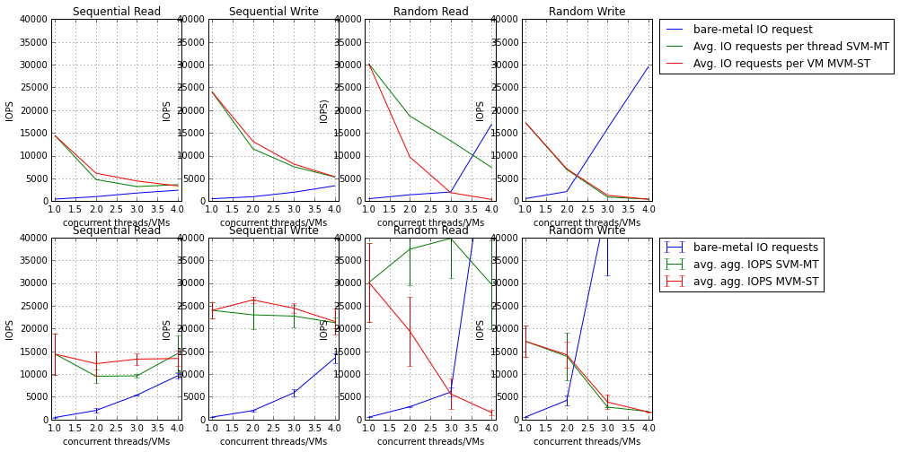

```python
x_axis = [1,2,3,4]

plt.subplot(241)
plt.plot(x_axis, iopssrbf, x_axis, iopssrsvm, x_axis, iopssrmvm)
plt.axis([0.9, 4.1, 0, 40000])
plt.grid(True)
plt.title('Sequential Read')
pylab.xlabel('concurrent threads/VMs')
pylab.ylabel('IOPS')

plt.subplot(242)
plt.plot(x_axis, iopsswbf, x_axis, iopsswsvm, x_axis, iopsswmvm)
plt.axis([0.9, 4.1, 0, 40000])
plt.grid(True)
plt.title('Sequential Write')
pylab.xlabel('concurrent threads/VMs')
pylab.ylabel('IOPS')

plt.subplot(243)
plt.plot(x_axis, iopsrrbf, x_axis, iopsrrsvm, x_axis, iopsrrmvm)
plt.axis([0.9, 4.1, 0, 40000])
plt.grid(True)
plt.title('Random Read')
pylab.xlabel('concurrent threads/VMs')
pylab.ylabel('IOPS)')

plt.subplot(244)
plt.plot(x_axis, iopsrwbf, label = 'bare-metal IO request')
plt.plot(x_axis, iopsrwsvm, label = 'Avg. IO requests per thread SVM-MT')
plt.plot(x_axis, iopsrwmvm, label = 'Avg. IO requests per VM MVM-ST')
plt.axis([0.9, 4.1, 0, 40000])
plt.grid(True)
plt.title('Random Write')
plt.legend(bbox_to_anchor=(1.05, 1), loc=2, borderaxespad=0.)
pylab.xlabel('concurrent threads/VMs')
pylab.ylabel('IOPS')

plt.subplot(245)
plt.errorbar(x_axis, aggiopssrbf, ciaggiopssrbf)
plt.errorbar(x_axis, aggiopssrsvm, ciaggiopssrsvm)
plt.errorbar(x_axis, aggiopssrmvm, ciaggiopssrmvm)
plt.axis([0.9, 4.1, 0, 40000])
plt.grid(True)
plt.title('Sequential Read')
pylab.xlabel('concurrent threads/VMs')
pylab.ylabel('IOPS')

plt.subplot(246)
plt.errorbar(x_axis, aggiopsswbf, ciaggiopsswbf)
plt.errorbar(x_axis, aggiopsswsvm, ciaggiopsswsvm)
plt.errorbar(x_axis, aggiopsswmvm, ciaggiopsswmvm)
plt.axis([0.9, 4.1, 0, 40000])
plt.grid(True)
plt.title('Sequential Write')
pylab.xlabel('concurrent threads/VMs')
pylab.ylabel('IOPS')

plt.subplot(247)
plt.errorbar(x_axis, aggiopsrrbf, ciaggiopsrrbf)
plt.errorbar(x_axis, aggiopsrrsvm, ciaggiopsrrsvm)
plt.errorbar(x_axis, aggiopsrrmvm, ciaggiopsrrmvm)
plt.axis([0.9, 4.1, 0, 40000])
plt.grid(True)
plt.title('Random Read')
pylab.xlabel('concurrent threads/VMs')
pylab.ylabel('IOPS')

plt.subplot(248)
plt.errorbar(x_axis, aggiopsrwbf, ciaggiopsrwbf, label = 'bare-metal IO requests')
plt.errorbar(x_axis, aggiopsrwsvm, ciaggiopsrwsvm, label = 'avg. agg. IOPS SVM-MT')
plt.errorbar(x_axis, aggiopsrwmvm, ciaggiopsrwmvm, label = 'avg. agg. IOPS MVM-ST')
plt.axis([0.9, 4.1, 0, 40000])
plt.grid(True)
plt.title('Random Write')
plt.legend(bbox_to_anchor=(1.05, 1), loc=2, borderaxespad=0.)
pylab.xlabel('concurrent threads/VMs')
pylab.ylabel('IOPS')
```

Input-Output Per Second (IOPS) – a measure of how many read and write commands a disk can complete in a second Note: Bare-metal doesn't give the IOPS measurement. The input data was wrong. The data for VM cases are also very ridiculous. Some articals point out that theorial maximum IOPS for an HDD with 7200rpm just about 189, and actual value is around 169.

**Read more**: Storage Basics:

- http://vmtoday.com/2009/12/storage-basics-part-i-intro/
- http://vmtoday.com/2009/12/storage-basics-part-ii-iops/
- http://vmtoday.com/2010/01/storage-basics-part-iii-raid/
- http://vmtoday.com/2010/01/storage-basics-part-iv-interface/
- http://vmtoday.com/2010/03/storage-basics-part-v-controllers-cache-and-coalescing/
- http://vmtoday.com/2010/04/storage-basics-part-vi-storage-workload-characterization/
- http://don.blogs.smugmug.com/2007/10/08/hdd-iops-limiting-factor-seek-or-rpm/
- http://www.sqlservercentral.com/blogs/sqlmanofmystery/archive/2009/12/07/fundamentals-of-storage-systems-raid-an-introduction.aspx
- http://blog.aarondelp.com/2009/10/its-now-all-about-iops.html